# d_featEng

```python
import os
import sys

# print(f"Current Working Directory --> {os.getcwd()}")
#Add one directory above research
parent_dir = os.path.abspath(os.path.join(os.getcwd(), "..")) # Get the parent directory
sys.path.append(parent_dir)
current_working_dir = %pwd

print(f"Parent Dir >>> {parent_dir}")
print(f"Current Working Dir >>> {current_working_dir}")

# from configs import cfgs  # Absolute import
```

```
Parent Dir >>> C:\Users\maz\dev\Projects_\alzheimer
Current Working Dir >>> C:\Users\maz\dev\Projects_\alzheimer\research
```

```python
import warnings

warnings.filterwarnings('ignore', category=UserWarning)
warnings.filterwarnings('ignore', category=DeprecationWarning)
# warnings.filterwarnings('ignore', category=np.VisibleDeprecationWarning)
```

### Imports

```python
from pathlib import Path
import numpy as np
import pandas as pd
import matplotlib.pyplot as plt
import seaborn as sns
import plotly.express as px
import plotly.graph_objects as go
from sklearn.preprocessing import FunctionTransformer
from sklearn.pipeline import Pipeline
import pprint
import ipywidgets as widgets
from IPython.display import display
from autogluon.tabular import TabularPredictor, TabularDataset

pp = pprint.PrettyPrinter(indent=2)

# Custom Functions
from utils import *
```

#### Paths

```python
# Create a path object
# dataset_dir = cfgs["DATASET_DIR"]
dataset_dir = "..//dataset//modified"
dataset_path = Path(dataset_dir)
print("Dataset Path")
print("*"*12)
print(f"Dataset: {dataset_path}")
print("\n")

# Find all CSV files inside the directory
files = list(dataset_path.glob("*.csv"))

print("Files in Dataset Dir:")
print("*"*21)
for file_path in files:
    print(file_path.name)  # Print only the file name


# Combining multiple paths
# path_metadata = dataset_path / "MetaData.xlsx"
path_train = dataset_path / "train.csv"
path_test = dataset_path / "test.csv"
path_train_new = dataset_path / "train_with_featEng.csv"

print("\n")
print(f"Train File Path --> {path_train}")
print(f"Test File Path --> {path_test}")
```

```
Dataset Path
************
Dataset: ..\dataset\modified


Files in Dataset Dir:
test.csv
test_features.csv
test_labels.csv
train.csv
train_features.csv
train_labels.csv
train_without_featEng.csv
train_with_featEng.csv


Train File Path --> ..\dataset\modified\train.csv
Test File Path --> ..\dataset\modified\test.csv
```

#### Vars

```python
SPECIFIC_COL_TO_DROP = ['Year']

THRESHOLD_RATIO = 0.1
MAX_UNIQUE = 50

# These are rudundant features
COLS_TO_DROP = ['UID', 'imss_03', 'imss_12', 'issste_03', 'issste_12', 'pem_def_mar_03', 'pem_def_mar_12',
                   'insur_private_03', 'insur_private_12', 'insur_other_03', 'insur_other_12', 'seg_pop_12',
                   'Tired_03', 'Tired_12', 'Happy_03', 'Happy_12']

THRESHOLD_MISSING = 70.0

NUM_STRATEGY = "median"
CAT_STRATEGY = "mode"

THRESHOLD_QUASI_CONSTANT = 0.00000001 # 0.01 (drops -> cols: 23), 0.005 (drops -> cols: 18), 0.00000001
```

#### Data Loading

##### We will load cleaned file which is saved in notebook `1_eda.ipynb`

```python
# pd.set_option("display.max_columns", None)
# pd.set_option("display.max_rows", None)
```

```python
try:
    data = pd.read_csv(path_train, encoding = 'utf8')
    df = data.copy()
    display(df.head(2))
    print(df.shape)
except FileNotFoundError:
    print("Error: 'train.csv' not found. Please ensure the file is in the correct location.")
    df = None
```

|  | UID | Year | composite_score | Age_03 | Urban_03 | Married_03 | Marriages_03 | Education_03 | Num_Living_Child_03 | Migration_03 | ... | Meet_FnF_12 | SocialActivities_12 | AttendReligiousServices_12 | a16a_12 | YrsLivedInUSA_12 | a22_12 | a33b_12 | SpeaksEnglish_12 | HousingEnvironment_12 | PredictionYear |
| --- | --- | --- | --- | --- | --- | --- | --- | --- | --- | --- | --- | --- | --- | --- | --- | --- | --- | --- | --- | --- | --- |
| 0 | aard | 2021 | 104 | 50-59 | Urban | Widowed | 1.0 | 7-9 Years | 1 or 2 | 0.0 | ... | Once a week | Never | 1.0 | NaN | NaN | NaN | NaN | 0.0 | Concrete | 9 |
| 1 | abme | 2021 | 106 | 50-59 | Rural | Married or In Civil Union | 1.0 | 1-5 Years | 5 or 6 | 0.0 | ... | Never | Never | 0.0 | NaN | NaN | NaN | NaN | 0.0 | Concrete | 9 |

2 rows × 185 columns

```
(2889, 185)
```

```python
cols_in_original_df = len(df.columns)
print(f"Columns in Original Data: {cols_in_original_df}")
```

```
Columns in Original Data: 185
```

#### Examine Data

```python
# dfTrain.info(verbose=True, show_counts=True)
```

```python
# # Get all dtypes as a Series
# all_dtypes = dfTrain.dtypes
# print("\nAll dtypes (Series):")
# print(all_dtypes)
# print("-" * 30)

# # Get unique dtypes
# unique_dtypes = dfTrain.dtypes.unique()
# print("\nUnique dtypes (NumPy array of dtype objects):")
# print(unique_dtypes)
# print("-" * 30)

dtype_summary_result = get_dtype_summary(df)

print("*" * 39)
print("Detailed Dtype Summary (from function):")
print("*" * 39)
# pp = pprint.PrettyPrinter(indent=2)
# pp.pprint(dtype_summary_result)
# pp.pprint(dtype_summary_result["float64"]["columns"])
print("\n")
print("*" * 20)
print("Data Type 'float64'")
print("*" * 20)
print(f"Data Type 'float64' ==> Total: {len(dtype_summary_result['float64']['columns'])}\n Columns Name: {dtype_summary_result['float64']['columns']}\n")
print("\n\n")
print("*" * 20)
print("Data Type 'int64'")
print("*" * 20)
print(f"Data Type 'int64' ==> Total: {len(dtype_summary_result['int64']['columns'])}\n Columns Name: {dtype_summary_result['int64']['columns']}\n")
print("\n\n")
print("*" * 20)
print("Data Type 'object'")
print("*" * 20)
print(f"Data Type 'object' ==> Total: {len(dtype_summary_result['object']['columns'])}\n Columns Name: {dtype_summary_result['object']['columns']}\n")
```

```
Detailed Dtype Summary (from function):


Data Type 'float64'
Data Type 'float64' ==> Total: 141
 Columns Name: ['Marriages_03', 'Migration_03', 'ADL_Dress_03', 'ADL_Walk_03', 'ADL_Bath_03', 'ADL_Eat_03', 'ADL_Bed_03', 'ADL_Toilet_03', 'Num_ADL_03', 'IADL_Money_03', 'IADL_Meds_03', 'IADL_Shop_03', 'IADL_Meals_03', 'Num_IADL_03', 'Depressed_03', 'Hard_03', 'Restless_03', 'Happy_03', 'Lonely_03',…




Data Type 'int64'
Data Type 'int64' ==> Total: 3
 Columns Name: ['Year', 'composite_score', 'PredictionYear']




Data Type 'object'
Data Type 'object' ==> Total: 41
 Columns Name: ['UID', 'Age_03', 'Urban_03', 'Married_03', 'Education_03', 'Num_Living_Child_03', 'GlobalHealth_03', 'BMI_03', 'FamilyDecisions_03', 'Employment_03', 'Age_12', 'Urban_12', 'Married_12', 'Education_12', 'Num_Living_Child_12', 'GlobalHealth_12', 'BMI_12', 'FamilyDecisions_12', 'Employm…
```

```python
# --- Define the Pipeline ---
# Note: The order matters if transformations depend on previous ones,

data_type_conversion = Pipeline([
    ('specific_categorizer', SpecificColumnCategorizer(columns_to_categorize=SPECIFIC_COL_TO_DROP)),
    ('object_to_category', ObjectToCategoryTransformer(threshold_ratio=THRESHOLD_RATIO, max_unique=MAX_UNIQUE)),
    ('float_to_category', FloatToCategoryTransformer()),
    # ('bool_to_category', BooleanToCategoryTransformer())
])

dropColumns = Pipeline([
    ('drop_columns', ColumnDropper(columns_to_drop=COLS_TO_DROP)),
])

dropColumnsHighNA = Pipeline([
    ('drop_columns_high_na', DropColumnsHighNA(threshold=THRESHOLD_MISSING)),
])

missingValueImputer = Pipeline([
    ('missing_value_imputer', MissingValueImputer(num_strategy=NUM_STRATEGY, cat_strategy=CAT_STRATEGY)),
])

identifyAndDropLowVarNum = Pipeline([
    ('identify_and_drop_low_var_num', IdentifyAndDropLowVarNum(quasi_constant_threshold=THRESHOLD_QUASI_CONSTANT)),
])

# Create a transformer step from your custom function
temporal_feature_engineering = Pipeline([
    ('temporal_features', FunctionTransformer(engineer_temporal_features, kw_args={'drop_originals': True}))
])

dataPreprocessing_pipeline = Pipeline([
    ('1_data_type_conversion', data_type_conversion),
    ('2_drop_columns', dropColumns),
    ('3_drop_high_na_columns', dropColumnsHighNA),
    ('4_impute_missing_values', missingValueImputer),
    ('5_identify_and_drop_low_var_num', identifyAndDropLowVarNum),
    # You can add more steps here, e.g., scaling, encoding, etc.
    # ('5_scaling', StandardScaler()), # Example
    ('6_temporal_feature_engineering', temporal_feature_engineering)
])
```

```python
%%capture
print("*" * 48)
print("--- Applying Pipeline | Data Preprocessing ---")
print("*" * 48, "\n")

df = dataPreprocessing_pipeline.fit_transform(df)
```

```python
print(f"--- PipeLine Completed ---")
```

```
--- PipeLine Completed ---
```

```python
print("*" * 30)
print("After Conversion of Data Types")
print("*" * 30)
# Get all dtypes as a Series
all_dtypes = df.dtypes
print("-" * 20)
print("All dtypes (Series):")
print("-" * 20)
print(f"All Data Types -> {all_dtypes}")

# Get unique dtypes
unique_dtypes = df.dtypes.unique()
print("-" * 45)
print("Unique dtypes (NumPy array of dtype objects):")
print("-" * 45)
print(f"Unique Data Types -> {unique_dtypes}")

# Get Columns Names
print("-" * 39)
print("Column Names After Feature Engineering:")
print("-" * 39)
print(f"{df.columns}")

print("-" * 44)
print("Number of Columns after Feature Engineering:")
print("-" * 44)
cols_after_featEng = len(df.columns)
print(f"{cols_after_featEng}")
```

```
After Conversion of Data Types
--------------------
All dtypes (Series):
--------------------
All Data Types -> Year                    category
composite_score            int64
Gender                  category
EducationMother         category
EducationFather         category
                          ...
changed_Cancer             int32
changed_Visit_Dr           int32
changed_Tobacco            int32
delta_SpouseEarnings     float64
changed_Diabetes           int32
Length: 70, dtype: object
---------------------------------------------
Unique dtypes (NumPy array of dtype objects):
---------------------------------------------
Unique Data Types -> [CategoricalDtype(categories=[2016, 2021], ordered=False, categories_dtype=int64)
 dtype('int64')
 CategoricalDtype(categories=['Man', 'Woman'], ordered=False, categories_dtype=object)
 CategoricalDtype(categories=['More than Primary', 'Primary', 'Some Primary'], ordered=False, categories_dtype=object)
 dtype('float64') dtype('int32')]
---------------------------------------
Column Names After Feature Engineering:
---------------------------------------
Index(['Year', 'composite_score', 'Gender', 'EducationMother',
       'EducationFather', 'PredictionYear', 'delta_hinc_rent',
       'changed_Num_Living_Child', 'changed_Alcohol', 'changed_ADL_Bath',
       'changed_Migration', 'delta_Marriages', 'changed_Visit_Dental',
       'changed_GlobalHealth', 'changed_Restless', 'delta_Num_ADL',
       'changed_OutPatient', 'changed_Married', 'changed_Insured',
       'changed_Test_BloodPress', 'delta_hincome', 'changed_ADL_Walk',
       'delta_Earnings', 'changed_CES-D_Symptoms', 'changed_SpouseGender',
       'changed_ADL_Eat', 'changed_Test_Diabetes', 'delta_SpousePension',
       'changed_IADL_Meals', 'changed_Lonely', 'delta_Num_CES-D_Symptoms',
       'changed_Hypertension', 'changed_Test_Cholestrol',
       'delta_Num_Illnesses', 'delta_Num_IADL', 'changed_Arthritis',
       'changed_ADL_Toilet', 'changed_Stroke', 'delta_Pension',
       'changed_Education', 'changed_Test_Tuber', 'changed_ADL_Dress',
       'changed_Employment', 'delta_JobHrsWeekly', 'delta_hinc_business',
       'changed_BMI', 'changed_IADL_Money', 'changed_Urban', 'changed_Enjoy',
       'changed_Hard', 'changed_Depressed', 'changed_Sad',
       'changed_FamilyDecisions', 'delta_hinc_cap', 'changed_IADL_Meds',
       'changed_IADL_Shop', 'changed_Respiratory_Illness', 'changed_Age',
       'changed_ADL_Bed', 'changed_Hospitalized', 'changed_Exercise',
       'delta_hinc_assets', 'changed_HeartAttack', 'changed_Energetic',
       'changed_Religon_Imp', 'changed_Cancer', 'changed_Visit_Dr',
       'changed_Tobacco', 'delta_SpouseEarnings', 'changed_Diabetes'],
      dtype='object')
--------------------------------------------
Number of Columns after Feature Engineering:
--------------------------------------------
70
```

#### Correlation Matrix

```
Plotting Correlation Matrix Using SNS | HeatMap
```

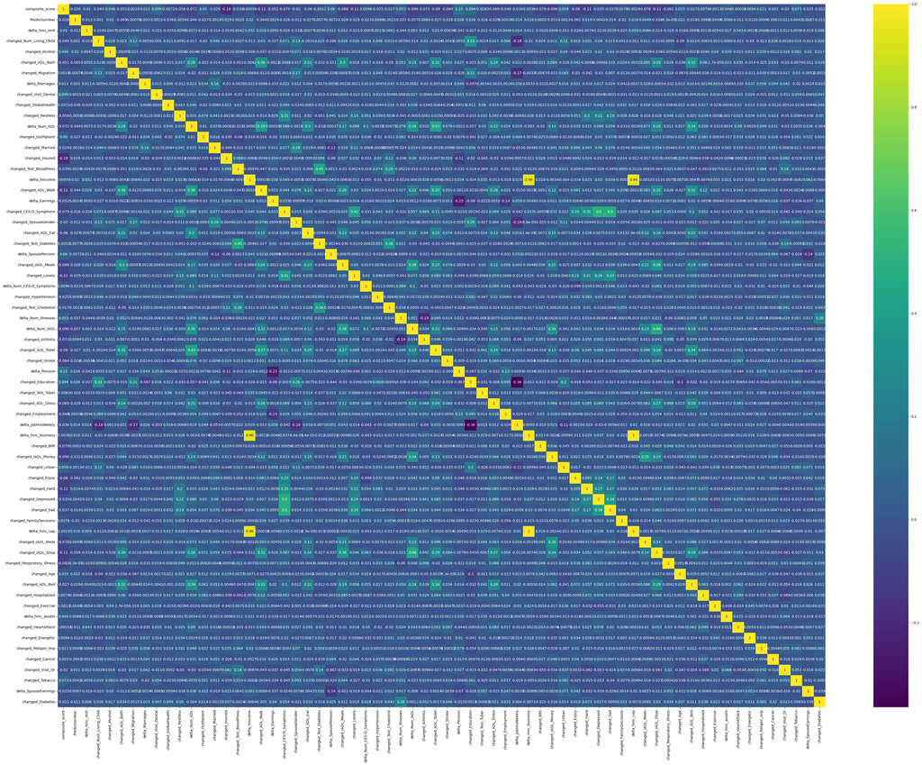

```
Identify highly correlated features
Highly Correlated Features | Above threshold of 0.7:
- `delta_hinc_business` and `delta_hincome`: 0.96
- `delta_hinc_cap` and `delta_hincome`: 0.96
- `delta_hinc_cap` and `delta_hinc_business`: 1.00


Custom thresholds (absolute values)

Low Magnitude Correlations:
- `changed_ADL_Walk` and `changed_ADL_Bath`: 0.36 (abs: 0.36)
- `changed_ADL_Walk` and `delta_Num_ADL`: 0.38 (abs: 0.38)
- `changed_CES-D_Symptoms` and `changed_Restless`: 0.31 (abs: 0.31)
- `changed_Test_Diabetes` and `changed_Test_BloodPress`: 0.45 (abs: 0.45)
- `changed_IADL_Meals` and `changed_ADL_Bath`: 0.30 (abs: 0.30)
- `changed_Lonely` and `changed_CES-D_Symptoms`: 0.41 (abs: 0.41)
- `changed_Test_Cholestrol` and `changed_Test_Diabetes`: 0.36 (abs: 0.36)
- `delta_Num_IADL` and `delta_Num_ADL`: 0.36 (abs: 0.36)
- `delta_Num_IADL` and `changed_IADL_Meals`: 0.38 (abs: 0.38)
- `changed_ADL_Toilet` and `changed_ADL_Bath`: 0.31 (abs: 0.31)
- `changed_ADL_Toilet` and `delta_Num_ADL`: 0.43 (abs: 0.43)
- `changed_ADL_Toilet` and `changed_ADL_Walk`: 0.37 (abs: 0.37)
- `changed_Education` and `changed_Num_Living_Child`: 0.33 (abs: 0.33)
- `delta_JobHrsWeekly` and `changed_Education`: -0.36 (abs: 0.36)
- `changed_IADL_Money` and `delta_Num_IADL`: 0.34 (abs: 0.34)
- `changed_Hard` and `changed_CES-D_Symptoms`: 0.35 (abs: 0.35)
- `changed_Depressed` and `changed_CES-D_Symptoms`: 0.50 (abs: 0.50)
- `changed_Sad` and `changed_CES-D_Symptoms`: 0.50 (abs: 0.50)
- `changed_Sad` and `changed_Lonely`: 0.33 (abs: 0.33)
- `changed_Sad` and `changed_Depressed`: 0.38 (abs: 0.38)
- `changed_IADL_Meds` and `changed_IADL_Money`: 0.35 (abs: 0.35)
- `changed_IADL_Shop` and `changed_ADL_Walk`: 0.32 (abs: 0.32)
- `changed_IADL_Shop` and `changed_IADL_Meals`: 0.36 (abs: 0.36)
- `changed_IADL_Shop` and `delta_Num_IADL`: 0.46 (abs: 0.46)
- `changed_ADL_Bed` and `changed_ADL_Bath`: 0.32 (abs: 0.32)
- `changed_ADL_Bed` and `delta_Num_ADL`: 0.34 (abs: 0.34)
- `changed_ADL_Bed` and `changed_ADL_Walk`: 0.32 (abs: 0.32)
- `changed_ADL_Bed` and `changed_ADL_Toilet`: 0.34 (abs: 0.34)

High Magnitude Correlations:
- `delta_hinc_business` and `delta_hincome`: 0.96 (abs: 0.96)
- `delta_hinc_cap` and `delta_hincome`: 0.96 (abs: 0.96)
- `delta_hinc_cap` and `delta_hinc_business`: 1.00 (abs: 1.00)


Custom thresholds (directional)

Moderate Positive Correlations:
- `changed_Test_Diabetes` and `changed_Test_BloodPress`: 0.45
- `changed_Lonely` and `changed_CES-D_Symptoms`: 0.41
- `changed_ADL_Toilet` and `delta_Num_ADL`: 0.43
- `changed_Depressed` and `changed_CES-D_Symptoms`: 0.50
- `changed_Sad` and `changed_CES-D_Symptoms`: 0.50
- `changed_IADL_Shop` and `delta_Num_IADL`: 0.46

Strong Positive Correlations:
- `delta_hinc_business` and `delta_hincome`: 0.96
- `delta_hinc_cap` and `delta_hincome`: 0.96
- `delta_hinc_cap` and `delta_hinc_business`: 1.00
```

```python
# # Calculate the correlation matrix
correlation_matrix = df.corr(numeric_only = True)

# --- SNS Plot ----
print("*" * 48)
print("Plotting Correlation Matrix Using SNS | HeatMap")
print("*" * 48)
plt.figure(figsize = (40, 30))
sns.heatmap(correlation_matrix, annot = True, cmap="viridis")
plt.tight_layout()
plt.show()

# # --- Plotly Plot ----
# print("*" * 38)
# print("Plotting Correlation Matrix Using Plotly | HeatMap")
# print("*" * 38)
# plot_correlation_heatmap_seaborn(
#     df, background_color="white", text_color="black",
#     color_scale="Viridis",  # Plotly named colorscale (e.g., 'Viridis', 'Plasma', 'Blues', 'Reds')
#     title="Correlation Matrix | Heatmap", decimal_places_annot=2,  # For annotation rounding
#     # width=1200, height=800
# )


print("*" * 35)
print("Identify highly correlated features")
print("*" * 35)
THRESHOLD_CORR = 0.7 # Define a correlation threshold (adjust as needed)
highly_correlated_pairs = []

for i in range(len(correlation_matrix.columns)):
    for j in range(i):  # Avoid redundant comparisons and diagonal elements
        if abs(correlation_matrix.iloc[i, j]) > THRESHOLD_CORR:
            col1 = correlation_matrix.columns[i]
            col2 = correlation_matrix.columns[j]
            correlation = correlation_matrix.iloc[i, j]
            highly_correlated_pairs.append((col1, col2, correlation))

# Print the highly correlated pairs
if highly_correlated_pairs:
    print(f"Highly Correlated Features | Above threshold of {THRESHOLD_CORR}:")
    for col1, col2, correlation in highly_correlated_pairs:
        print(f"- `{col1}` and `{col2}`: {correlation:.2f}")
else:
    print("No highly correlated features found above the threshold.")


print("\n")
print("*" * 35)
print("Custom thresholds (absolute values)")
print("*" * 35)
custom_abs_thresholds = {
    "low_magnitude": (0.3, 0.5),  # |corr| in [0.3, 0.5)
    "medium_magnitude": (0.5, 0.8),  # |corr| in [0.5, 0.8)
    "high_magnitude": (0.8, 1.000001),  # |corr| in [0.8, 1.0]
}
correlation_results_custom_abs = analyze_feature_correlations(df, thresholds=custom_abs_thresholds)
for level, pairs in correlation_results_custom_abs.items():
    if pairs:
        print(f"\n{level.replace('_', ' ').title()} Correlations:")
        for col1, col2, corr_val in pairs:
            print(f"- `{col1}` and `{col2}`: {corr_val:.2f} (abs: {abs(corr_val):.2f})")

print("\n")
print("*" * 31)
print("Custom thresholds (directional)")
print("*" * 31)
custom_dir_thresholds = {
    "moderate_positive": (0.4, 0.7),
    "strong_positive": (0.7, 1.000001),
    "moderate_negative": (-0.7, -0.4),
    "strong_negative": (-1.000001, -0.7),
}
correlation_results_custom_dir = analyze_feature_correlations(df, thresholds=custom_dir_thresholds)
for level, pairs in correlation_results_custom_dir.items():
    if pairs:
        print(f"\n{level.replace('_', ' ').title()} Correlations:")
        for col1, col2, corr_val in pairs:
            print(f"- `{col1}` and `{col2}`: {corr_val:.2f}")
```

### Correlations: Unpacking the Heatmap

First, let's establish some general thresholds for "low," "medium," and "high" correlation (absolute values):

- **Low:** |r| < 0.3
- **Medium:** 0.3 <= |r| < 0.7
- **High:** |r| >= 0.7

Our goal is to understand how different factors relate to the `composite_score` and how these factors relate to each other, which can inform feature selection for a predictive model.

### Detailed Analysis of the Engineered Feature Correlation Matrix

This comprehensive analysis evaluates newly engineered features. We will first examine their relationship with the target variable, composite_score, and then address the significant multicollinearity that remains within the dataset.

### Feature Correlations with `composite_score`

By examining the first column of correlation matrix heatmap, we can assess the linear relationship between each engineered feature and the target variable, `composite_score`.

Even after feature engineering, the correlations with the target variable remain generally weak. However, some signals are more notable than others:

**Other Correlations:**

- Nearly all other features, including the delta_ income variables (`delta_hincome`, `delta_hinc_business`, etc.), have a correlation with composite_score that is very close to zero. This indicates they have a negligible direct linear relationship with the target variable on their own.

### Echoes in the Data - Multicollinearity Among Features

Analysis correctly identifies that a critical issue of multicollinearity persists, even with the new "delta" features. This means some features are providing redundant information.

**High Correlation Pairs (Threshold > 0.7):**

- `delta_hinc_business` and `delta_hincome` `(0.96)`: The change in business income and the change in total household income are nearly identical.
- `delta_hinc_cap` and `delta_hincome` `(0.96)`: The change in capital income and the change in total household income are also nearly identical.
- `delta_hinc_cap` and `delta_hinc_business` `(1.00)`: This is a perfect correlation. These two features are completely redundant. They measure the exact same change and are interchangeable.

**Summary for Multicollinearity:**

The core problem of redundant financial features remains. The `delta_hincome`, `delta_hinc_business`, and `delta_hinc_cap` variables are so highly correlated that they are essentially "echoes" of one another. Including more than one of these in a model is highly problematic, as it can make it impossible to determine the individual contribution of each feature and can lead to an unstable model.

### Feature Pruning - Suggestions for Simplification

To create a robust model, we must eliminate this redundancy. The best practice is to keep only one feature from a highly correlated group. The decision of which to keep is ideally based on which one has the strongest relationship with the target variable (composite_score).

- Group: `delta_hincome`, `delta_hinc_business`, `delta_hinc_cap`
  - Relationship with Target: As noted from the heatmap, all three have a correlation very close to `zero` with composite_score `(~0.005 or less)`.
  - Decision: Since none of them shows a meaningful correlation with the target, any of them could theoretically be kept as the representative for the group. However, `delta_hincome` is often the most logical choice as it represents the overall change in household income and is the most encompassing and interpretable of the three.
  - Suggestion: Keep `delta_hincome` and remove `delta_hinc_business` and `delta_hinc_cap`.

### Narrative Conclusion & Recommendations

Feature engineering was successful in transforming the data to capture changes over time. This has shifted the focus from static income levels to dynamic changes in a person's life. The key insight is that changes in health and mental well-being are more strongly correlated with the composite_score than changes in financial status.

However, the fundamental issue of `multicollinearity` among the `income` sources persists in the new `delta features`. To move forward, it is essential to simplify the model by removing these redundant "echoes." This will allow the model to focus on the unique information provided by the remaining features and to more accurately weigh the importance of factors like depressive symptoms and daily-living assistance.

## To build a more robust and interpretable model, recommendations are the following feature selection strategy:

Based on the severe `multicollinearity` and lack of a `distinct signal` towards the `target`, the following features should be removed:

- Remove `delta_hinc_business`: It is `perfectly correlated` with `delta_hinc_cap` and `almost perfectly correlated` with `delta_hincome`, offering no new information.
- `Remove delta_hinc_cap`: For the same reason, this feature is redundant and should be removed.

By retaining `delta_hincome`, you keep a single, interpretable measure of `income change` while completely resolving the `multicollinearity` issue within this group of features. This will result in a cleaner, more stable, and more reliable predictive model.

#### Relationship Between `Year` and `composite_score`

```python
# visualize_comparison_violin(df, "composite_score", "Year", background_color="white", text_color="black", width=1000, height=600)
```

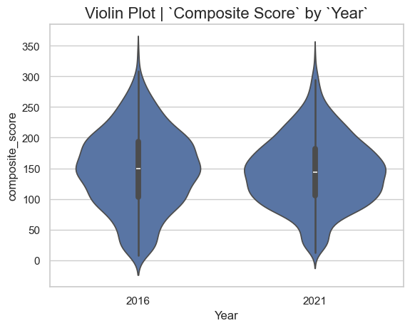

```python
sns.set(style = 'whitegrid')
ax = sns.violinplot(x="Year", y="composite_score",
            # hue ="",
            # palette="Set2",
            # dodge=True,
            data = df)

ax.set_title("Violin Plot | `Composite Score` by `Year`", fontsize=16)
plt.show()
```

#### Analysis of `Composite Score` Distribution: `2016` vs. `2021`

- **Interquartile Range (IQR = Q3 - Q1):**
  - 2016: Q1 = 103, Q3 = 194. **IQR = 91**.
  - 2021: Q1 = 105, Q3 = 182. **IQR = 77**.
    - **Insight Point:** The IQR is noticeably smaller in 2021. This means the middle 50% of the `composite_score` data is more tightly clustered around the median in 2021 compared to 2016, where it was more spread out.
- **Fences (Typical Range, excluding outliers):**
  - 2016: Lower fence = 8, Upper fence = 308.
  - 2021: Lower fence = 12, Upper fence = 295.
    - **Insight Point:** The "typical" range of scores (as defined by the fences) has also contracted slightly in 2021, especially at the higher end. The minimum typical score went up a bit, and the maximum typical score came down.
- **Overall Range (Min to Max):**
  - 2016: Min = 8, Max = 334. Range = 326.
  - 2021: Min = 12, Max = 332. Range = 320.
    - **Insight Point:** The absolute overall range is quite similar, but the slight shifts in min/max contribute to the sense of a slightly more compressed distribution in 2021.

##### Putting it Together - The Narrative:

An analysis of `composite_scores` between `2016` and `2021` reveals a subtle but interesting evolution in their distribution.

In 2021, the **median score (144) was slightly lower** than in 2016 (149). More significantly, the scores in 2021 demonstrated **less variability in the central part of the distribution**. The interquartile range (IQR), which captures the middle 50% of scores, shrank from 91 in 2016 to 77 in 2021. This indicates that a larger proportion of individuals in 2021 scored closer to the median compared to 2016, where scores were more spread out.

This tightening is also reflected in the typical range of scores (defined by the fences), which contracted slightly in 2021, particularly at the upper end. While both years saw individuals achieving exceptionally high scores (outliers), the 2016 data showed a slightly wider overall spread, including a few more instances of very low scores.

In essence, the `composite_score` landscape in 2021 was characterized by scores that were, on average, a touch lower and more homogeneously grouped around the typical values, compared to the slightly higher average and more dispersed scores seen in 2016.

##### Potential Follow-up Questions This Story Might Lead To:

- What factors could have contributed to this slight decrease in median and tightening of the distribution? (e.g., changes in the assessment, demographic shifts, interventions, external factors).
- Are these observed differences statistically significant? (You'd need to run a statistical test like a Mann-Whitney U test).
- How do these changes correlate with other features in your dataset?

#### Save to .CSV

```python
COLS_TO_DROP_FT_ENG = ['delta_hinc_business', 'delta_hinc_cap']

dropColumns_after_feat_eng = Pipeline([
    ('drop_columns_after_feat_eng', ColumnDropper(columns_to_drop=COLS_TO_DROP_FT_ENG)),
])

dataPreprocessing_pipeline = Pipeline([
    ('drop_columns', dropColumns_after_feat_eng),
])


print("*" * 48)
print("--- Applying Pipeline | Data Preprocessing ---")
print("*" * 48, "\n")

df = dataPreprocessing_pipeline.fit_transform(df)
```

```
--- Applying Pipeline | Data Preprocessing ---

ColumnDropper: Dropped columns: ['delta_hinc_business', 'delta_hinc_cap']
```

```python
print("-" * 42)
print("Number of Columns after Feature Engineering/Drop Columns:")
print("-" * 42)
cols_after_featEng = len(df.columns)
print(f"{cols_after_featEng}")
```

```
------------------------------------------
Number of Columns after Feature Engineering/Drop Columns:
------------------------------------------
68
```

```python
df.to_csv(path_train_new, index=False, encoding="utf8")
print(f"Path to Save Cleaned File: {path_train_new}")
```

```
Path to Save Cleaned File: ..\dataset\modified\train_with_featEng.csv
```